# Project 2

Justin Williams

2024-10-22

Let’s load some data and packages!

```r
library(tidyverse)
library(dplyr)

# Load the data from the CSV file into a data frame
HRData_New <- read_csv("/Users/justinwilliams/Code/9050advresearch/Project 2/HRData_New.csv")
hrdata_df <- data.frame(HRData_New)
```

# 1. Report the descriptive statistics along with the frequency distribution and provide a detailed interpretation of how you would characterize the salary variable.

## Summary statistics

```r
## Summary statistics
summary(hrdata_df$Salary)
```

```
##    Min. 1st Qu.  Median    Mean 3rd Qu.    Max.
##   45046   55502   62810   69021   72036  250000
```

```r
## Mean
mean_salary <- mean(hrdata_df$Salary, na.rm = TRUE)
print(mean_salary)
```

```
## [1] 69020.68
```

```r
## Median
median_salary <- median(hrdata_df$Salary, na.rm = TRUE)
print(median_salary)
```

```
## [1] 62810
```

```r
## Mode
mode_salary <- function(x) {
  ux <- unique(x)
  ux[which.max(tabulate(match(x, ux)))]
}
mode_salary_value <- mode_salary(hrdata_df$Salary)
print(mode_salary_value)
```

```
## [1] 57815
```

```r
## Frequency table
salary_table <- table(hrdata_df$Salary)
print(salary_table)
```

```
##
##  45046  45069  45115  45395  45433  45998  46120  46335  46428  46430  46654
##      1      1      1      1      1      1      1      1      1      1      1
##  46664  46738  46799  46837  46998  47001  47211  47414  47434  47750  47837
##      1      1      1      1      1      1      1      1      1      1      1
##  47961  48285  48413  48495  48513  48888  49256  49773  49920  50178  50274
##      1      1      1      1      1      1      1      1      1      1      1
##  50373  50428  50470  50482  50750  50825  50923  51044  51259  51337  51505
##      1      1      1      1      1      1      1      1      1      1      1
##  51777  51908  51920  52057  52087  52177  52249  52505  52599  52624  52674
##      1      1      1      1      1      1      1      1      1      1      1
##  52788  52846  52984  53018  53060  53171  53180  53189  53250  53366  53492
##      1      1      1      1      1      1      1      1      1      1      1
##  53564  54005  54132  54237  54285  54670  54828  54933  55000  55140  55315
##      1      1      1      1      1      1      1      1      1      1      1
```

[output cut: 42 more lines]

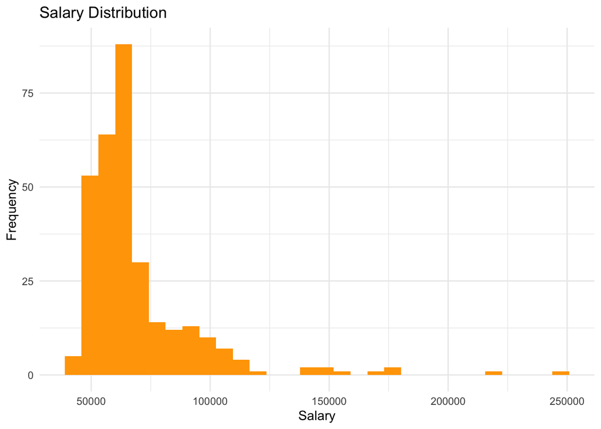

```r
## Plot
hrdata_df %>%
  ggplot(aes(x = Salary)) +
  geom_histogram(fill = "orange", bins = 30) +
  labs(title = "Salary Distribution", x = "Salary", y = "Frequency") +
  theme_minimal()
```

[output not shown]

[output not shown]

[output not shown]

[output not shown]

### Detailed Interpretation

- The mean salary is $69,020.68, which indicates the average salary of the employees. The range is large as well as a large variation in salaries as the max salary is $250,00, which is a high end outlier. The mean salary is higher than the median salary, meaning that the distribution is right-skewed suggesting that most employees earn less than the mean.
- The median salary is $62,810, which is the middle value when the salaries are sorted in ascending order. The median gives us a more accurate view of what the typical employee is earning, due to the right-skewness of the distribution which impacts the mean. This could be due to company factors such as the majority of positions in the comapny being more junior.
- The mode salary is $57,815, which is the most frequently occurring salary in the dataset. The mode being less than both the mean and median again shows the right-skewness of the distribution.
- The frequency distribution bar plot shows the distribution of salaries across different ranges. This helps in visualizing how salaries are spread out among the employees.

Overall, the salary distribution is spread across a wide range of values with the majority of employees falling below the mean. A small number of employees earn significantly higher salaries than the rest, as indicated by the maximum salary of $250,000. The median may be a better measure of central tendency in this case due to the presence of large outliers.